# Practical Machine Learning Assignment

Bassey Orok

22 April 2016

```r
setwd("~/Desktop/Coursera_wd")
library(knitr)
```

# load useful libraries

```r
library(caret)
library(rpart)
library(RColorBrewer)
library(knitr)
library(tree)
library(rattle)
library(randomForest)
```

### Downloading the data

```r
fileUrl <- "https://d396qusza40orc.cloudfront.net/predmachlearn/pml-training.csv"
download.file(fileUrl, destfile = "./pmlData/pml-training.csv", method="curl")

fileUrl2 <- "https://d396qusza40orc.cloudfront.net/predmachlearn/pml-testing.csv"
download.file(fileUrl, destfile = "./pmlData/pml-testing.csv", method="curl")
```

### question to answer

You should create a report describing how you built your model, how you used cross validation, what you think the expected out of sample error is, and why you made the choices you did.

### Load the requied package/library

```r
library(caret)
```

### Retrieve downloaded data and assign to variables

```r
set.seed(1234)
trainingDat = read.csv("pmlData/pml-training.csv", na.strings=c("", "NA", "NULL"))


testingDat = read.csv("pmlData/pml-testing.csv", na.strings=c("", "NA", "NULL"))
```

### Check dimensions of the data

```r
dim(trainingDat)
```

```
## [1] 19622   160
```

```r
dim(testingDat)
```

```
## [1] 19622   160
```

### Some house keeping to clean the data inorder to reduce the number of predictors

```r
training.redu <- trainingDat[ , colSums(is.na(trainingDat)) == 0]
dim(training.redu)
```

```
## [1] 19622    60
```

### Remove unwanted variables

```r
remove = c('X', 'user_name', 'raw_timestamp_part_1', 'raw_timestamp_part_2', 'cvtd_timestamp', 'new_window', 'num_window')
training.redu <- training.redu[, -which(names(training.redu) %in% remove)]

dim(training.redu)
```

```
## [1] 19622    53
```

```r
# only numeric variables can be evaluated in this way.

zeroVar= nearZeroVar(training.redu[sapply(training.redu, is.numeric)], saveMetrics = TRUE)
training.nonzerovar = training.redu[,zeroVar[, 'nzv']==0]
dim(training.nonzerovar)
```

```
## [1] 19622    53
```

```r
# only numeric variabls can be evaluated in this way.
corrMatrix <- cor(na.omit(training.nonzerovar[sapply(training.nonzerovar, is.numeric)]))
dim(corrMatrix)
```

```
## [1] 52 52
```

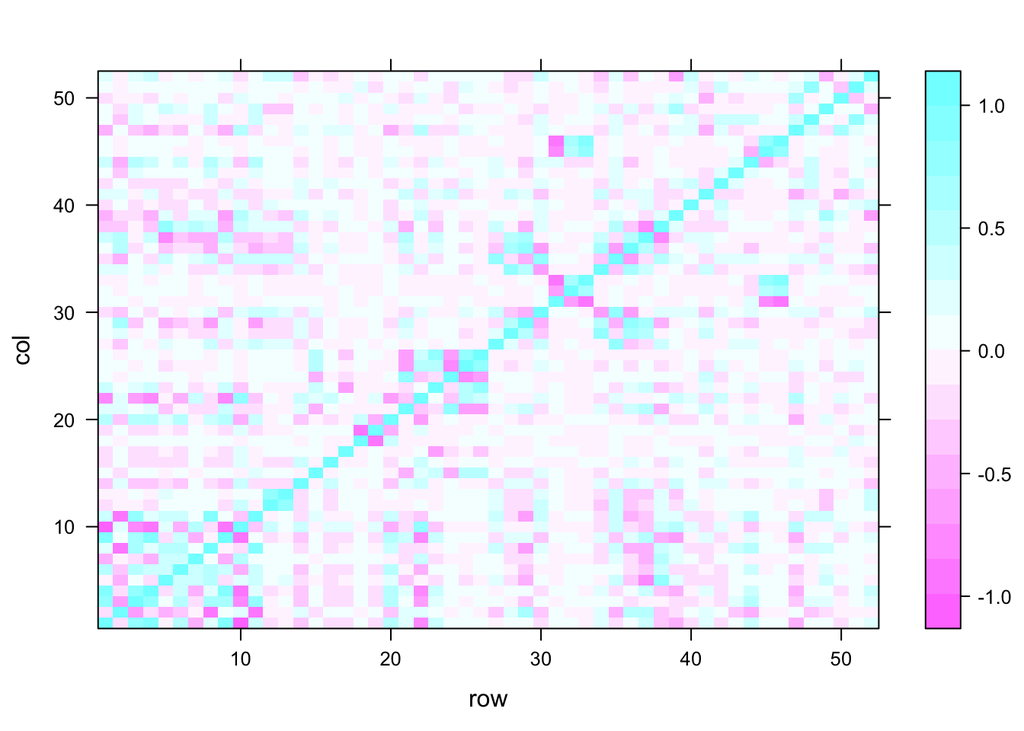

```r
corrDF <- expand.grid(row = 1:52, col = 1:52)
corrDF$correlation <- as.vector(corrMatrix)
levelplot(correlation ~ row + col, corrDF)
```

### We are going to remove those variables which have high correlation

```r
removecor = findCorrelation(corrMatrix, cutoff = .90, verbose = TRUE)
```

```
## Compare row 10  and column  1 with corr  0.992
##   Means:  0.27 vs 0.168 so flagging column 10
## Compare row 1  and column  9 with corr  0.925
##   Means:  0.25 vs 0.164 so flagging column 1
## Compare row 9  and column  4 with corr  0.928
##   Means:  0.233 vs 0.161 so flagging column 9
## Compare row 8  and column  2 with corr  0.966
##   Means:  0.245 vs 0.157 so flagging column 8
## Compare row 19  and column  18 with corr  0.918
##   Means:  0.091 vs 0.158 so flagging column 18
## Compare row 46  and column  31 with corr  0.914
##   Means:  0.101 vs 0.161 so flagging column 31
## Compare row 46  and column  33 with corr  0.933
##   Means:  0.083 vs 0.164 so flagging column 33
## All correlations <= 0.9
```

```r
training.nocor = training.nonzerovar[,-removecor]
dim(training.nocor)
```

```
## [1] 19622    46
```

### Conduct cross validation by splitting the training.nocor data into training and testing data sets

```r
inTrain <- createDataPartition(y=training.nocor$classe, p=0.7, list=FALSE)
training <- training.nocor[inTrain,]
testing <- training.nocor[-inTrain,]
dim(training)
```

```
## [1] 13737    46
```

```r
dim(testing)
```

```
## [1] 5885   46
```

# Data Analysis and Predictions

```r
set.seed(3334)
tree_training <- tree(classe ~., data = training)
summary(tree_training)
```

```
##
## Classification tree:
## tree(formula = classe ~ ., data = training)
## Variables actually used in tree construction:
##  [1] "pitch_forearm"     "magnet_belt_y"     "accel_forearm_z"
##  [4] "magnet_dumbbell_y" "roll_forearm"      "magnet_dumbbell_z"
##  [7] "accel_dumbbell_y"  "pitch_belt"        "yaw_belt"
## [10] "accel_forearm_x"   "yaw_dumbbell"      "magnet_forearm_y"
## [13] "accel_dumbbell_z"  "gyros_belt_z"
## Number of terminal nodes:  20
## Residual mean deviance:  1.665 = 22840 / 13720
## Misclassification error rate: 0.3272 = 4495 / 13737
```

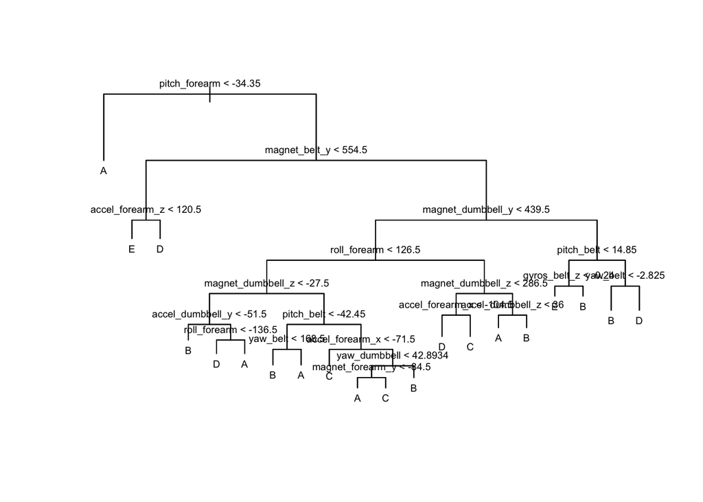

```r
plot(tree_training)
text(tree_training,pretty= 0, cex = .6)
```

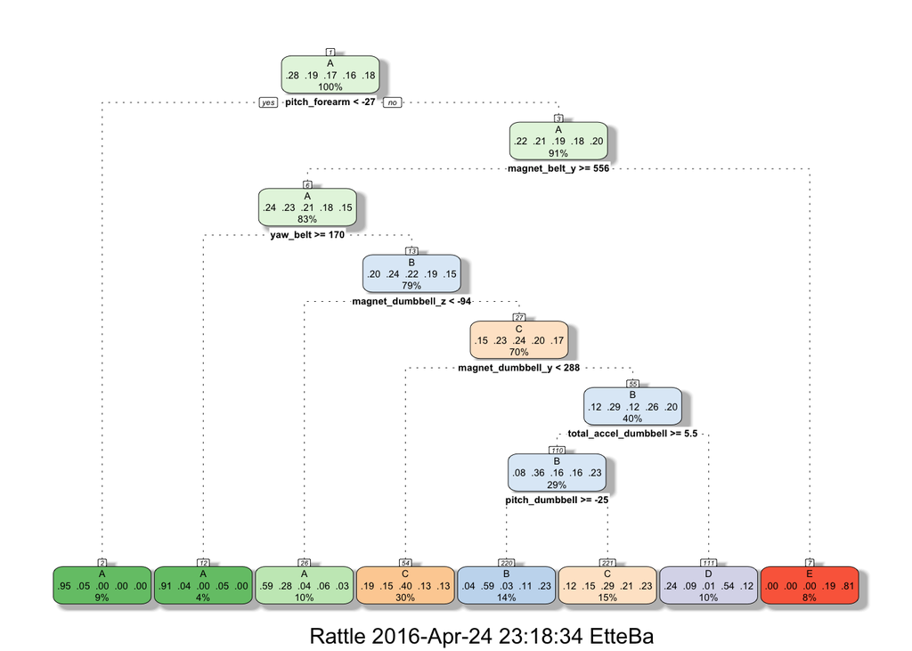

```r
set.seed(12345)
modFit <- train(classe ~ ., data=training, method="rpart")
fancyRpartPlot(modFit$finalModel)
```

### To check the performance of the tree we have to do some cross validation on the testing data

```r
tree_pred<-predict(tree_training,testing,type="class")
predMatrix<-with(testing,table(tree_pred,classe))
sum(diag(predMatrix))/sum(as.vector(predMatrix)) # this is the error rate
```

```
## [1] 0.6565845
```

```r
tree_pred<-predict(modFit ,testing)
predMatrix<-with(testing,table(tree_pred,classe))
sum(diag(predMatrix))/sum(as.vector(predMatrix)) # this is the error rate
```

```
## [1] 0.5305013
```

```r
training_cv <-cv.tree(tree_training,FUN=prune.misclass)

training_cv
```

```
## $size
##  [1] 20 19 17 16 15 14 13 10  7  5  1
##
## $dev
##  [1] 4761 4828 4984 5275 5466 5565 5857 6472 6656 7201 9761
##
## $k
##  [1]     -Inf  76.0000 115.5000 138.0000 149.0000 159.0000 175.0000
##  [8] 198.3333 220.0000 262.5000 657.0000
##
## $method
## [1] "misclass"
##
## attr(,"class")
## [1] "prune"         "tree.sequence"
```

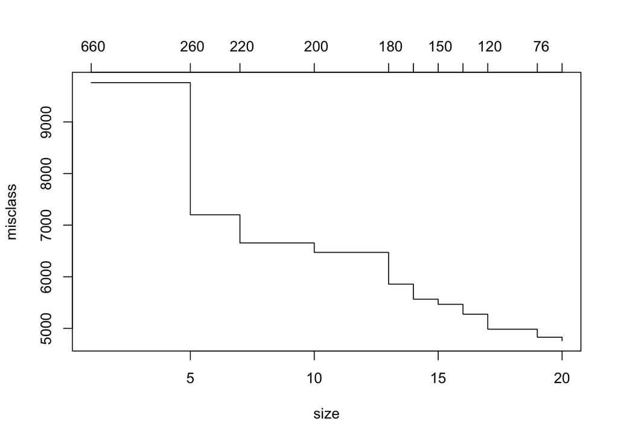

```r
plot(training_cv)
```

### To get a simplere result and a more interprtable tree we have to prune the tree.

```r
prune.training<- prune.misclass(tree_training,best=18)
```

```r
tree_pred<-predict(prune.training,testing,type="class")
predMatrix <- with(testing,table(tree_pred,classe))
sum(diag(predMatrix))/sum(as.vector(predMatrix)) # error rate
```

```
## [1] 0.6513169
```

Prunning the tree didn’t give any marked difference in the results.

To improve on accuracy we would employ another method

## Random Forest

```r
set.seed(14567)
# we fit a model to the random forest
rf_training <- randomForest(classe~.,data=training,ntree=100, importance=TRUE)
rf_training
```

```
##
## Call:
##  randomForest(formula = classe ~ ., data = training, ntree = 100,      importance = TRUE)
##                Type of random forest: classification
##                      Number of trees: 100
## No. of variables tried at each split: 6
##
##         OOB estimate of  error rate: 0.63%
## Confusion matrix:
##      A    B    C    D    E  class.error
## A 3903    3    0    0    0 0.0007680492
## B   16 2632    9    1    0 0.0097817908
## C    0   18 2375    3    0 0.0087646077
## D    0    0   26 2224    2 0.0124333925
## E    0    0    2    6 2517 0.0031683168
```

This gives and error rate of 0.63%

We will now test of thE out of Sample Accuracy

# Out of Sample Accuracy

```r
tree.pred=predict(rf_training,testing,type="class")
predMatrix = with(testing,table(tree.pred,classe))
sum(diag(predMatrix))/sum(as.vector(predMatrix)) # error rate
```

```
## [1] 0.9960918
```

0.995 implies that our estimate is accurate.

```r
ans <- predict(rf_training, testingDat)

ans
```

[output not shown]

[output not shown]